# Report_StormData.Rmd

Sabin Khadka

August 21, 2015

# Exploratory data analysis from U.S National Oceanic and Atmospheric Administration’s storm database

## Synopsis

In current report, we report the impact of weather on health-related impact on general population and property damages. The data was exported from U.S. National Oceanic and Atmospheric Administration’s (NOAA) storm database. The data contained characterisctics of major storms and weather events in the U.S, their occurence and estimates of fatalities, injuries and property damage. There were 935 unique events reported. All these events were grouped and recoded to 13 common event types. Here we report sum of health related damage (both injuries and fatalities) and property damage (both crop and property) by events.

## Data analysis

Load all the necessary R libraries.

```r
library(ggplot2)
library(dplyr)
library(reshape2)
```

### Data reading

Here we parse and get only subset of columns from data that are related to health, property and events.

```r
knitr::opts_chunk$set(cache=TRUE)
data <- read.csv(bzfile("repdata_data_StormData.csv.bz2"), header=T, sep=",")
col_interest <- which(colnames(data) %in% c("BGN_DATE", "STATE", "EVTYPE", "INJURIES", "FATALITIES","PROPDMG","PROPDMGEXP","CROPDMG","CROPDMGEXP") )
data <- data[,col_interest]
```

To exclude data from the year with less data, we checked number of data present per year.

```r
data$year = as.numeric(format(as.Date(data$BGN_DATE, format = "%m/%d/%Y"), "%Y"))
nyear <- data$year
n_obs.year <- as.data.frame(table(nyear))
```

```r
data1 <- subset(data, data$year > 1988)
```

We recode the events type to 13 common event types.

```r
eventsTYPE <- unique(data$EVTYPE)
evTABLE <- matrix(unlist(eventsTYPE), ncol = 5, byrow = TRUE)
totatEventType <- length(eventsTYPE)
ptrn1 <- grepl("burst|depression|drizzle|fog|precipitation|percip|rain|wet|wall cloud",
               data1$EVTYPE, ignore.case = TRUE)
ptrn2 <- grepl("hail", data1$EVTYPE, ignore.case = TRUE)
ptrn3 <- grepl("hurricane|typhoon|storm|wind|wnd", data1$EVTYPE, ignore.case = TRUE)
ptrn4 <- grepl("erosion|slide|slump", data1$EVTYPE, ignore.case = TRUE)
ptrn5 <- grepl("dry|drought|heat|hot|record temperature|record high|thermia|temperature record|warmth|warm",
               data1$EVTYPE, ignore.case = TRUE)
ptrn6 <- grepl("avalanche|blizzard|chill|cold|cool|ice|frost|freeze|freezing|glaze|icy|snow|sleet|winter|wintry|wintery",
               data1$EVTYPE, ignore.case = TRUE)
ptrn7 <- grepl("dam break|flood|fld|surf|swells", data1$EVTYPE, ignore.case = TRUE)
ptrn8 <- grepl("current|drowning|high water|marine|seas|tide|tsunami|wave", data1$EVTYPE, ignore.case = TRUE)
ptrn9 <- grepl("dust|saharan", data1$EVTYPE, ignore.case = TRUE)
ptrn10 <- grepl("lightning|tstm|thunderstorm", data1$EVTYPE, ignore.case = TRUE)
ptrn11 <- grepl("funnel|spout|tornado|whirlwind", data1$EVTYPE, ignore.case = TRUE)
ptrn12 <- grepl("fire|smoke", data1$EVTYPE, ignore.case = TRUE)
ptrn13 <- grepl("volcanic", data1$EVTYPE, ignore.case = TRUE)
# Assign new event code
data1$NewEVCODE <- NA
data1$NewEVCODE[ptrn1] <- "Rain-related"
data1$NewEVCODE[ptrn2] <- "Hail"
data1$NewEVCODE[ptrn3] <- "Wind-related"
data1$NewEVCODE[ptrn4] <- "Soil-related"
data1$NewEVCODE[ptrn5] <- "Heat-related"
data1$NewEVCODE[ptrn6] <- "Snow/Ice"
data1$NewEVCODE[ptrn7] <- "Flood/Water-related"
data1$NewEVCODE[ptrn8] <- "Sea-related"
data1$NewEVCODE[ptrn9] <- "Dust/Saharan winds"
data1$NewEVCODE[ptrn10] <- "Thunderstorm/Lightning"
data1$NewEVCODE[ptrn11] <- "Tornado"
data1$NewEVCODE[ptrn12] <- "Fire-related"
data1$NewEVCODE[ptrn13] <- "Volcano"
data1$NewEVCODE <- as.factor(data1$NewEVCODE)
```

Since some of the values of the damages were expressed in alphabets, we change them to numeric form. Also, we derive total damage amount by adding property damage and crop damage.

```r
convertStr2power <- function(x) {
    if (is.numeric(x)) {
        x <- x
    }
    else if (grepl("h|H", x, ignore.case=T)) {
        x <- 2
    }
    else if (grepl("k|K", x, ignore.case=T)) {
        x <- 3
    }
    else if (grepl("m|M", x, ignore.case=T)) {
        x <- 6
    }
    else if (grepl("b|B", x, ignore.case=T)) {
        x <- 9
    }
    else {
        x <- 0
    }
}

Convert_amt <- function(amt, power){
    power1 <- convertStr2power(power)
    if(is.numeric(amt)){
        tot_amt <- amt * 10^power1
    }
    else if(!is.numeric(amt)){
        tot_amt <- 0
    }
    tot_amt
}

addTWO <- function(x,y){
    tot <- x+y
    tot
}

data1$PROP_DMG_amt <- 0
data1$CROP_DMG_amt <- 0
data1$Total_DMG_amt <- 0
data1$PROP_DMG_amt <- mapply(Convert_amt, data1$PROPDMG, data1$PROPDMGEXP)
data1$CROP_DMG_amt <- mapply(Convert_amt, data1$CROPDMG, data1$CROPDMGEXP)
data1$Total_DMG_amt <- mapply(addTWO, data1$PROP_DMG_amt, data1$CROP_DMG_amt)
```

We calculated the total number of fatalities, injuries and total damage (in $ amount).

```r
Fatal_summary <- aggregate(data1$FATALITIES, by=list(data1$NewEVCODE), FUN=sum)
Injury_summary <- aggregate(data1$INJURIES, by=list(data1$NewEVCODE), FUN=sum)
Amount_summary <- aggregate(data1$Total_DMG_amt, by=list(data1$NewEVCODE), FUN=sum)
```

Here are the codes for the figures generated from the analysis.

```r
merge_result <- Fatal_summary
colnames(merge_result) <- c("Event_Types","Total_Fatalities")
merge_result[, "Total_Injury"] <- Injury_summary$x
merge_result[, "Total_Damage_amt"] <- Amount_summary$x
data2 <- merge_result[,1:3]
mdata2 <- melt(data2)
```

```r
png("./figure1.png")
p1 <- ggplot(data=mdata2, aes(x=Event_Types, y=value, fill=variable)) + geom_bar(stat="identity") +
    theme(axis.text.x = element_text(size=10, face = "bold",angle = 45, hjust =1))
p1 <- p1 +ggtitle("Total Health related ") + xlab("Event Types") + ylab("Health related Injuries/Fatalities")
print(p1)
dev.off()
```

Figure 1 below shows impact of various event types on population health

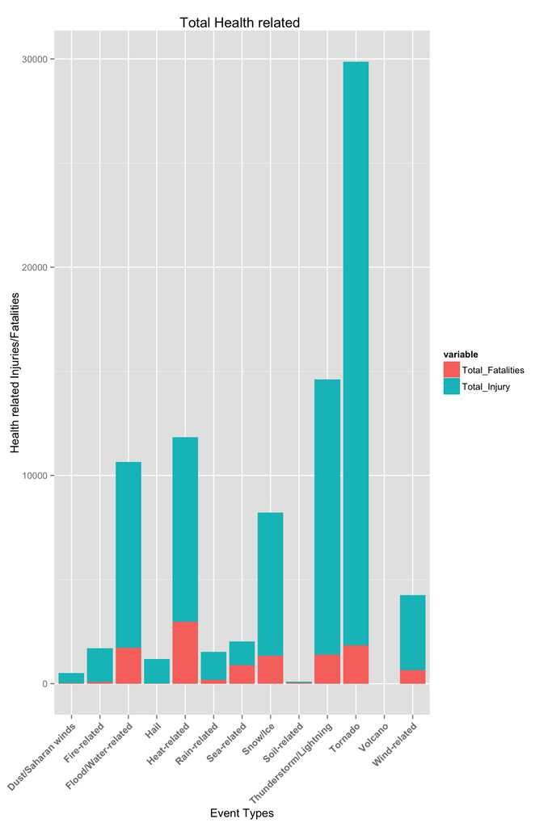

```r
png("./figure2.png")
p2 <- ggplot(data=merge_result, aes(x=Event_Types, y=Total_Damage_amt)) + geom_bar(fill="#DD8888",color="red",stat="identity") +
    theme(axis.text.x = element_text(size=10, face = "bold",angle = 45, hjust =1))
p2 <- p2 +ggtitle("Total loss in $") + xlab("Event Types") + ylab("Loss in $")
print(p2)
dev.off()
```

Figure 2 below shows impact of various event types on economy

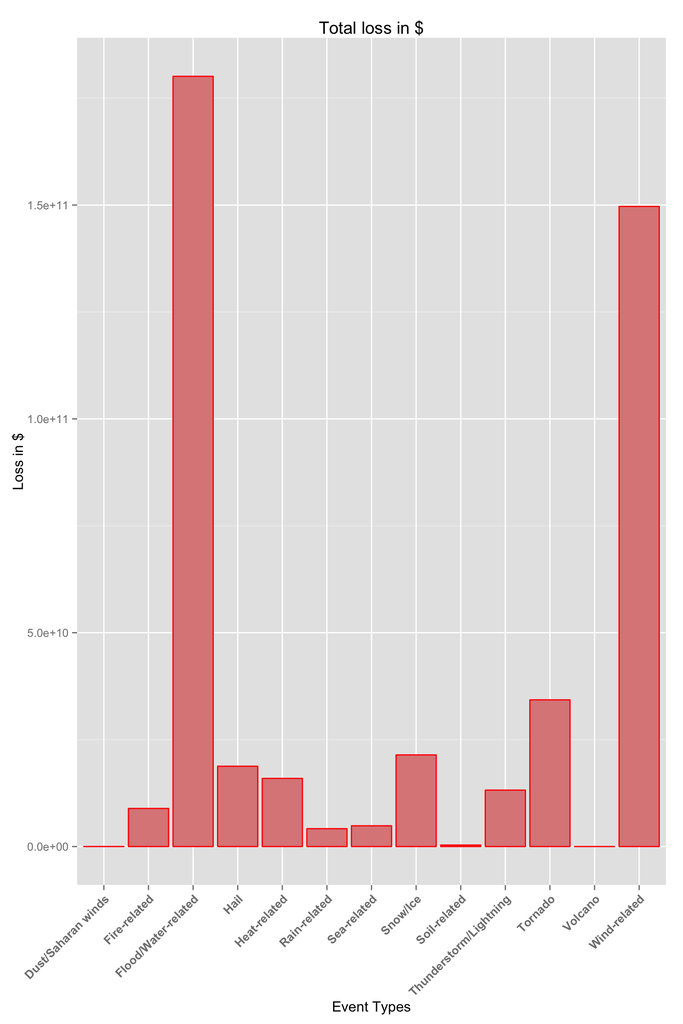